# Handin 4

#### Imports

```python
import numpy as np
from scipy.sparse import csr_matrix
from scipy.sparse import lil_matrix
import networkx as nx
import matplotlib.pyplot as plt
import operator
import itertools
import random as rand
import json
from networkx.readwrite import json_graph
```

```python
# See the attached .py file
import epidemics_package
```

Small note: For this handin I decided to build classes to make the code more genreral, these as well as some functions are found in the package *epidemics_package*. Some of the classes still lack formal documentation and my plan is to create a whole epidemics package with graphical interface once this semester is done. It is currently far from being a clean object-oriented design but I think you should be able to follow the code relatively well.

### Problem 1.1

1. The average number of newly infected individuals each week. In other words, you should plot how many people become infected each week (on the average).
2. The average total number of susceptible, infected, and recovered individuals at each week. In other words, you should plot how many individuals in total that are suscep- tible/infected/recovered at each week (on the average).

```python
d = 4 #degree
n = 500 # nodes
G = nx.watts_strogatz_graph(n, d, 0) # Graph object
```

```python
# Create a SIR object
sir = epidemics_package.SIR(G, beta=0.3, rho=0.7,print_out=True)
# Define the start nodes
source_nodes = [0, 499, 4, 278, 9, 29, 156, 84, 399, 299]
# Simulate the epidemic
sir.simulate_epidemic(source = source_nodes, max_time = 15)
```

```
Epidemic terminated in week 12 | susceptible: 88.8 % |  | infected: 11.2 % | recovered: 11.2 %
```

```python
# Using the multiple epidemics function found in the attached package.
average_susceptible,average_infected,average_recovered,average_new_infections, Na = epidemics_package.multiple_epidemics(G, beta=0.3, rho=0.7,source_nodes = source_nodes, time_limit=15,N=100)
```

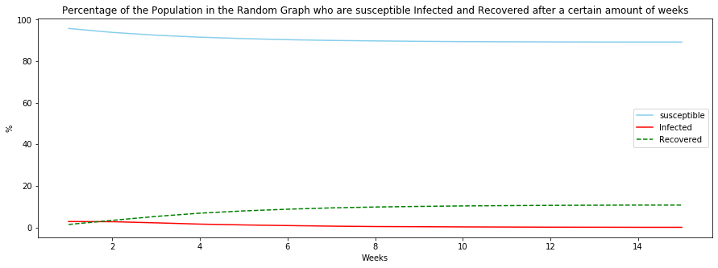

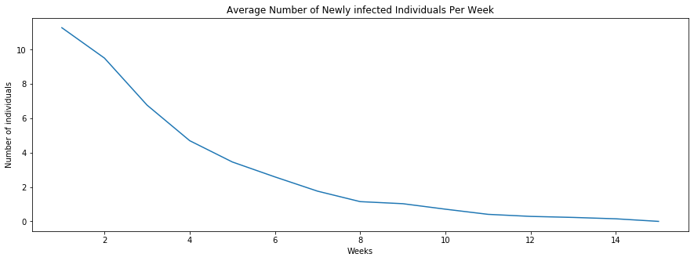

```python
# Plots. Would be nice to have these as a function instead!
x, y_new_infections = zip(*average_new_infections.items()) # unpack a list of pairs into two tuples
x, y_average_susceptible = zip(*average_susceptible.items())
x, y_average_infected = zip(*average_infected.items())
x, y_average_recovered = zip(*average_recovered.items())

plt.figure(1,figsize = (15,5))
plt.plot(x, y_average_susceptible, color = 'skyblue', label = 'susceptible')
plt.plot(x, y_average_infected, color = 'red', label = 'Infected')
plt.plot(x, y_average_recovered, color = 'green', linestyle = 'dashed', label = 'Recovered')
plt.ylabel('%')
plt.xlabel('Weeks')
plt.legend(loc = 'right')
plt.title('Percentage of the Population in the Random Graph who are susceptible Infected and Recovered after a certain amount of weeks')

plt.figure(2,figsize = (15,5))
plt.plot(x,y_new_infections)
plt.ylabel('Number of individuals')
plt.xlabel('Weeks')
plt.title('Average Number of Newly infected Individuals Per Week')


plt.show()
```

### 1.2 Generate a random graph

```python
G_pref = epidemics_package.preferential_attachment_graph(6,200)
print('Average degree: ' + str(np.mean(list(dict(G_pref.degree()).values()))))
print('Number of nodes: ' + str(len(G.nodes())))
```

```
Average degree: 6.0
Number of nodes: 500
```

Seems like the algorithm was successfully implemented

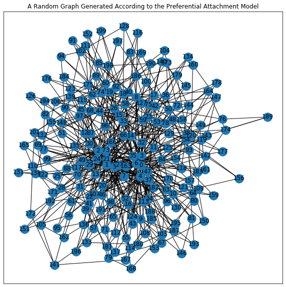

```python
# Just an example
plt.figure(figsize = (10,10))
nx.draw_networkx(G_pref)
plt.title('A Random Graph Generated According to the Preferential Attachment Model')
plt.show()
```

### 2 Simulate a pandemic without vaccination

```python
# Create a preferential attachment graph
G = epidemics_package.preferential_attachment_graph(6,500)
# Create a SIR object
sir2 = epidemics_package.SIR(G, beta=0.3, rho=0.7,print_out=True)
# Define the start nodes
source_nodes = [0, 499, 4, 278, 9, 29, 156, 84, 399, 299]
# Simulate the epidemic
sir2.simulate_epidemic(source = source_nodes, max_time = 15)
```

```
Epidemic terminated in week 13 | susceptible: 19.6 % |  | infected: 80.4 % | recovered: 80.4 %
```

```python
# Using the multiple epidemics function found in the attached package.
average_susceptible,average_infected,average_recovered,average_new_infections,i = epidemics_package.multiple_epidemics(G, beta=0.3, rho=0.7,source_nodes = source_nodes, time_limit=15,N=100)
```

[figure not shown]

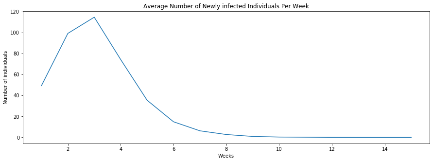

```python
x, y_new_infections = zip(*average_new_infections.items()) # unpack a list of pairs into two tuples
x, y_average_susceptible = zip(*average_susceptible.items())
x, y_average_infected = zip(*average_infected.items())
x, y_average_recovered = zip(*average_recovered.items())

plt.figure(1,figsize = (15,5))
plt.plot(x, y_average_susceptible, color = 'skyblue', label = 'susceptible')
plt.plot(x, y_average_infected, color = 'red', label = 'Infected')
plt.plot(x, y_average_recovered, color = 'green', linestyle = 'dashed', label = 'Recovered')
plt.ylabel('%')
plt.xlabel('Weeks')
plt.legend(loc = 'right')
plt.title('Percentage of the Population in the Random Graph who are susceptible Infected and Recovered after a certain amount of weeks')

plt.figure(2,figsize = (15,5))
plt.plot(x,y_new_infections)
plt.ylabel('Number of individuals')
plt.xlabel('Weeks')
plt.title('Average Number of Newly infected Individuals Per Week')


plt.show()
```

### 3 Simulate a pandemic with vaccination

```python
V = [0, 0.05, 0.15, 0.25, 0.35, 0.45, 0.55, 0.60, 0.60, 0.60, 0.60, 0.60, 0.60, 0.60, 0.60] # % of the population vaccinated in each week
# Creating a SIRV object, same as a SIR object with the exception of people being vaccinated.
sirv = epidemics_package.SIRV(G, 0.3, 0.7 ,V,print_out=True)
```

```python
sirv.simulate_epidemic(source = source_nodes, max_time = 15)
```

```
Epidemic terminated in week 10 | susceptible: 46.2 % |  | infected: 53.8 % | recovered: 53.8 %
```

As we can see, we are able to protect a much larger portion of the population with vaccination

```python
average_susceptible,average_infected,average_recovered,average_new_infections, new_vaccinations = epidemics_package.multiple_epidemics(G, beta=0.3, rho=0.7,source_nodes = source_nodes, V = V, time_limit=15,N=100)
```

[figure not shown]

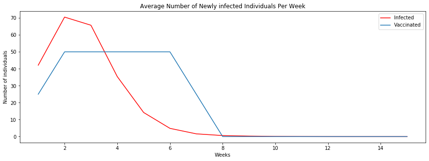

```python
x, y_new_infections = zip(*average_new_infections.items()) # unpack a list of pairs into two tuples
x, y_average_susceptible = zip(*average_susceptible.items())
x, y_average_infected = zip(*average_infected.items()) # unpack a list of pairs into two tuples
x, y_average_recovered = zip(*average_recovered.items()) # unpack a list of pairs into two tuples
x, y_new_vaccinated = zip(*new_vaccinations.items())

plt.figure(1,figsize = (15,5))
plt.plot(x, y_average_susceptible, color = 'skyblue', label = 'susceptible')
plt.plot(x, y_average_infected, color = 'red', label = 'Infected')
plt.plot(x, y_average_recovered, color = 'green', linestyle = 'dashed', label = 'Recovered')
plt.plot(x, [i*100 for i in V], label = 'Vaccinated')
plt.ylabel('%')
plt.xlabel('Weeks')
plt.legend(loc = 'upper right')
plt.title('Percentage of the Population in the Random Graph who are susceptible Infected and Recovered after a certain amount of weeks')

plt.figure(2,figsize = (15,5))
plt.plot(x,y_new_infections, color = 'red', label = 'Infected')
plt.plot(x,y_new_vaccinated, label = 'Vaccinated')
plt.legend(loc= 'upper right')
plt.ylabel('Number of individuals')
plt.xlabel('Weeks')
plt.title('Average Number of Newly infected Individuals Per Week')
plt.show()
```

## 4 The H1N1 pandemic in Sweden 2009

```python
V = [0.05, 0.09, 0.16, 0.24, 0.32, 0.40, 0.47, 0.54, 0.59, 0.60, 0.60, 0.60, 0.60, 0.60, 0.60, 0.60] # Vaccinated each week (in % of total population)
I = [1, 1, 3, 5, 9, 17, 32, 32, 17, 5, 2, 1, 0, 0, 0, 0] # Infected each week
```

```
Training finishedess. | Current iteration: 9| Current RMSE: 7.097534783289195 | Current params (5, 0.24, 0.53)
```

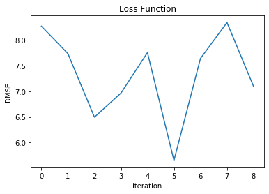

```
((5, 0.24, 0.53), 7.097534783289195)
```

```python
# IF possible run on GPU instead of CPU
optim = epidemics_package.Optimizer()
optim.stat_k()

epidemics_package.train(5, 0.3, 0.5,V,I, optim=optim, number_of_nodes=934, batch_size=10)
```

```python
G = epidemics_package.preferential_attachment_graph(5,934)
average_susceptible,average_infected,average_recovered,average_new_infections, new_vaccinations = epidemics_package.multiple_epidemics(G, beta=0.30, rho=0.55, V = V, time_limit=16,N=20)
```

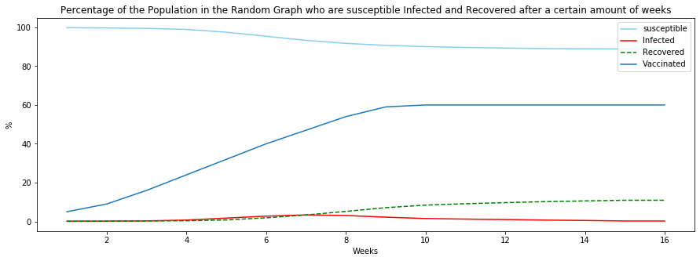

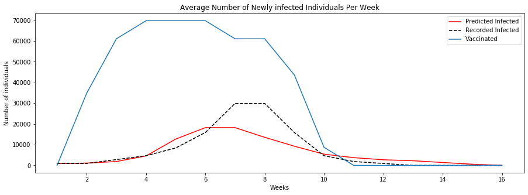

```python
x, y_new_infections = zip(*average_new_infections.items()) # unpack a list of pairs into two tuples
x, y_average_susceptible = zip(*average_susceptible.items())
x, y_average_infected = zip(*average_infected.items()) # unpack a list of pairs into two tuples
x, y_average_recovered = zip(*average_recovered.items()) # unpack a list of pairs into two tuples
x, y_new_vaccinated = zip(*new_vaccinations.items())

plt.figure(1,figsize = (15,5))
plt.plot(x, y_average_susceptible, color = 'skyblue', label = 'susceptible')
plt.plot(x, y_average_infected, color = 'red', label = 'Infected')
plt.plot(x, y_average_recovered, color = 'green', linestyle = 'dashed', label = 'Recovered')
plt.plot(x, [i*100 for i in V], label = 'Vaccinated')
plt.ylabel('%')
plt.xlabel('Weeks')
plt.legend(loc = 'upper right')
plt.title('Percentage of the Population in the Random Graph who are susceptible Infected and Recovered after a certain amount of weeks')



plt.figure(2,figsize = (15,5))
plt.plot(x,[i*934 for i in y_new_infections], color = 'red', label = 'Predicted Infected')
plt.plot(x,[i*934 for i in I], color = 'black', label = 'Recorded Infected', linestyle = 'dashed')


temp = [0] + np.diff([i*934 for i in V]).tolist()

plt.plot(x,[i*934 for i in temp], label = 'Vaccinated')
plt.legend(loc= 'upper right')
plt.ylabel('Number of individuals')
plt.xlabel('Weeks')
plt.title('Average Number of Newly infected Individuals Per Week')
plt.show()
```

## 5 Challenge

Try to find a better random graph (i.e. one that does not use preferential attachment) to represent the network for the pandemic. Try to also find a better algorithm to estimate the parameters.

Idea for graph is to use the Watts Stomgatz model instead of the preferential Attachment. Preferential Attachment has the benefit of being scale free compared to the Wattz Stomgatz. Thus we can for preferential attachement quite easily scale down, while for watts stomgatz we have to take this into consideration and find a way around this issue. Easiest way is simply to use a larger network but then it takes a longer time for us to train the model. A more realistic network to use would be to create several communities in the network where each community represents a city, could also use the airports as hubs and create small worlds around these and make connections between them.

```python
G = nx.watts_strogatz_graph(934, 6, 5)
```

```
Training finishedess. | Current iteration: 9| Current RMSE: 7.677076266392044 | Current params (6, 0.3, 0.56))
```

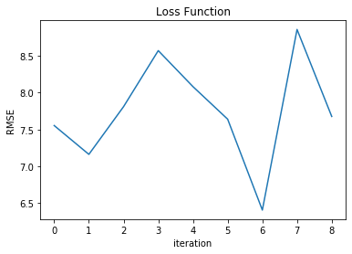

```
((6, 0.3, 0.56), 7.677076266392044)
```

```python
epidemics_package.train(6, 0.3, 0.5,V,I,source_nodes = [850], optim=optim, number_of_nodes=934, batch_size=1,graph_type = 'small_world')
```

```python
average_susceptible,average_infected,average_recovered,average_new_infections, new_vaccinations = epidemics_package.multiple_epidemics(G, beta=0.32, rho=0.59, V = V, time_limit=16,N=10)
```

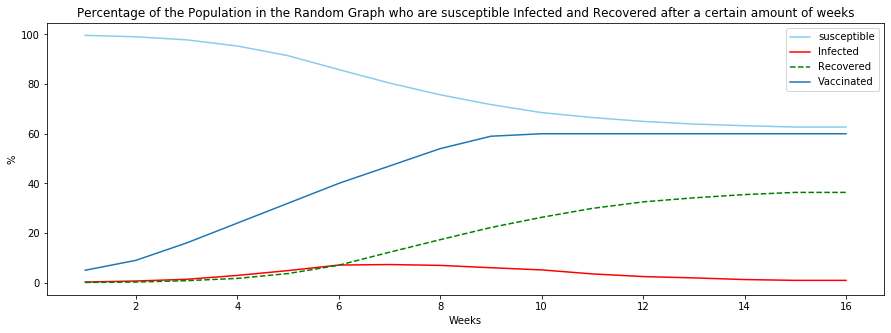

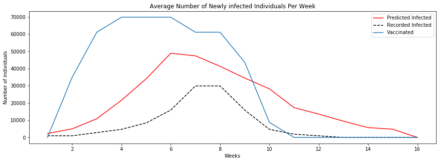

```python
x, y_new_infections = zip(*average_new_infections.items()) # unpack a list of pairs into two tuples
x, y_average_susceptible = zip(*average_susceptible.items())
x, y_average_infected = zip(*average_infected.items()) # unpack a list of pairs into two tuples
x, y_average_recovered = zip(*average_recovered.items()) # unpack a list of pairs into two tuples
x, y_new_vaccinated = zip(*new_vaccinations.items())

plt.figure(1,figsize = (15,5))
plt.plot(x, y_average_susceptible, color = 'skyblue', label = 'susceptible')
plt.plot(x, y_average_infected, color = 'red', label = 'Infected')
plt.plot(x, y_average_recovered, color = 'green', linestyle = 'dashed', label = 'Recovered')
plt.plot(x, [i*100 for i in V], label = 'Vaccinated')
plt.ylabel('%')
plt.xlabel('Weeks')
plt.legend(loc = 'upper right')
plt.title('Percentage of the Population in the Random Graph who are susceptible Infected and Recovered after a certain amount of weeks')



plt.figure(2,figsize = (15,5))
plt.plot(x,[i*934 for i in y_new_infections], color = 'red', label = 'Predicted Infected')
plt.plot(x,[i*934 for i in I], color = 'black', label = 'Recorded Infected', linestyle = 'dashed')


temp = [0] + np.diff([i*934 for i in V]).tolist()

plt.plot(x,[i*934 for i in temp], label = 'Vaccinated')
plt.legend(loc= 'upper right')
plt.ylabel('Number of individuals')
plt.xlabel('Weeks')
plt.title('Average Number of Newly infected Individuals Per Week')
plt.show()
```

We see that the Watts Stomgatz graph performs somewhat similar based on the loss function. The plots on the other hand show that the number of newly infected in the preferential attachemnt model more resembles our ground truth.

An algorithm that is better at estimating the parameters in the SIR modelling can be attaianed by updating the optimizer object every time we receive the same parameters that initiated an iteration (our previous stop condition). What would happen then is that the learning rates of the parameters would decrease with a factor of 2. This would give us a finer search. This is already implemented in the current train function, just set update = True.

The break condition could then be based on:

1. *max iterations reached* <- Currently the only thing that is used
2. *Low difference in RMSE between two rounds* <- could implement this as well, would be nice

There is one problem however in testing this algorithm and that can be seen by studying our loss function in our current training. Our current batch size is rather small when training so the loss function is very noisy. Using a larger loss function would mean that every time we are changing the parameters, we are more confident that it is a step that results in lower RMSE. Returning to the same parameters would then likely mean that we hit a local minimum, which we are not very sure if we do now. Then the algorithm would update the learning rates and start again.

### For Fun (How visualization can be used)

Using the network found in nyc_augmented_network.json we can get a road map over NYC where the nodes are the intersections. Using this map we can simulate how the epidemic propagates in an urban environment and get a nice visualization

```python
# Reading in the json-file and creating the graph
def read_json_file(filename):
    with open(filename) as f:
        js_graph = json.load(f)
    return json_graph.node_link_graph(js_graph)

def statGraph(Graph):
    print("The number of nodes is :",len(Graph.nodes()))
    print("The number of edges is :",len(Graph.edges()))

G = read_json_file('nyc_augmented_network.json')
statGraph(G)
```

```
The number of nodes is : 26481
The number of edges is : 43437
```

```python
sir = epidemics_package.SIR(G, beta=1.0, rho=0.2,print_out=True)
sir.simulate_epidemic(source = [0], max_time = 100)
```

```
Epidemic still progressing in week 100 | susceptible: 40.3874 % |  | infected: 59.6126 % | recovered: 56.331 %
```

```python
infection_date = sir.get_inf_time()
recovery_date = sir.get_rec_time()
```

```python
#Visualizes the graph with respect to the number of suceptible infected and recovered after d days.
def draw_network(Gr, d, with_edges, sir):
    (suceptible_colour, infected_colour, recovered_colour) = ('skyblue','red', 'green')
    node_colour = [suceptible_colour] * len(Gr.nodes())
    infection_day = sir.get_inf_time()
    recovered_day = sir.get_rec_time()
    max_days = 500
    for i in Gr.nodes():
        day_of_infection = infection_day[i]
        day_of_recovery = recovered_day[i]
        if day_of_infection <= d < day_of_recovery:
            node_colour[i] = infected_colour
        if day_of_recovery <= d < max_days:
            node_colour[i] = recovered_colour
    if with_edges is False:
        nx.draw_networkx_nodes(Gr, nx.get_node_attributes(Gr,'coordinates'), with_labels=False, node_size=1, node_color = node_colour)
    else:
        nx.draw_networkx(Gr, nx.get_node_attributes(Gr,'coordinates'), with_labels=False, node_size=1, node_color = node_colour)
```

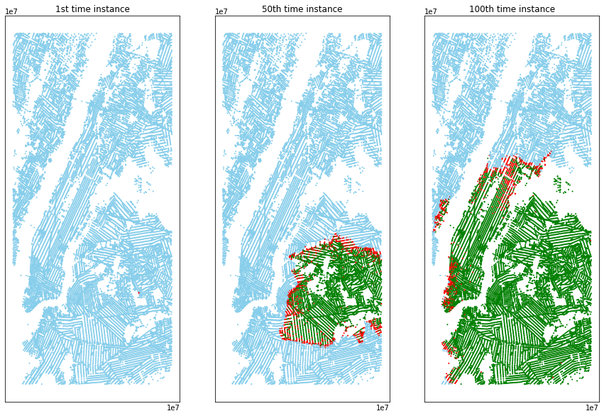

```python
f, axs = plt.subplots(2,2,figsize=(15,10))

plt.subplot(1, 3, 1)
draw_network(G,1,False, sir)
plt.title('1st time instance')
plt.subplot(1, 3, 2)
draw_network(G,50,False, sir)
plt.title('50th time instance')
plt.subplot(1, 3, 3)
draw_network(G,100,False, sir)
plt.title('100th time instance')
plt.show()
```

In order to get a reasonably well simulation here we should probably use a continous time simulation instead. How this should be formed and potential improvements I did not have time to do due to time constraints at the moment. It would be fun though to use visualizations in combination with plots like these and the one below in a GUI and expand the epidemics package. The example above is based on roads, another cool thing to use would be airlin routes. I found the following example online here: https://analyticfreaks.com/networkx-import-manipulate-visualize-network-python/. This could be done both locally in sweden, e.g by having several small worlds acting as the largest citites and then have them connected by a few edges acting as proxies for airports. Sorry if I went a little out of scope in the end here!

```python
# NOTE: this is not my work, just wanted to feature it.
import urllib.request
url = "https://raw.githubusercontent.com/jpatokal/openflights/master/data/airports.dat"
response = urllib.request.urlopen(url)
data = response.read()
file = open("airports_db.dat", "wb")
file.write(data)
file.close()


import csv

f = open("airports_db.dat", encoding = "utf8")
airport_db = [] #main arrar for airport
errors = 0
for airport in csv.reader(f, delimiter = ','):
    current_record = []
    try:
        #each slots containing information about an airport
        current_record.append(int(airport[0])) #airport ID
        current_record.append(airport[1])
        current_record.append(airport[2])
        current_record.append(airport[3])
        current_record.append(airport[4])
        current_record.append(airport[5])
        current_record.append(float(airport[6]))
        current_record.append(float(airport[7]))
        current_record.append(float(airport[8]))
        current_record.append(float(airport[9]))
        current_record.append(airport[10])
        current_record.append(airport[11])
        current_record.append(airport[12])
        current_record.append(airport[13])
    except :
        errors += 1
    else:
        airport_db.append(current_record)
print("Total Airport Imported : ", len(airport_db), "# of Errors : ", errors)
```

```
Total Airport Imported :  7345 # of Errors :  353
```

```python
url = "https://raw.githubusercontent.com/jpatokal/openflights/master/data/routes.dat"
response= ""
data = ""
response = urllib.request.urlopen(url)
data = response.read()

file = open("routes_db.dat", "wb")
file.write(data)
file.close()
```

```python
f = open("routes_db.dat", encoding = "utf8")
route_db = []
errors = 0
for route in csv.reader(f, delimiter = ','):
    current_record = []
    try:
        current_record.append(route[0])
        current_record.append(int(route[1]))
        current_record.append(int(route[3]))
        current_record.append(int(route[5]))
        current_record.append(int(route[7]))
        current_record.append(route[8])

    except :
        errors += 1
    else:
        route_db.append(current_record)
print("Total Routes Imported : ", len(route_db), "# of Errors : ", errors)
```

```
Total Routes Imported :  66765 # of Errors :  898
```

```python
network = nx.Graph()
for airport in airport_db:
    network.add_node(airport[0], id=airport[0], name=airport[1], city=airport[2], country=airport[3], iata=airport[4],
                     icao=airport[5],
                     lat=airport[6],
                     long=airport[7], alt=airport[8], offset=airport[9],
                     daylight=airport[10], timezone=airport[11], type=airport[12], source=airport[13])

for route in route_db:
    if route[2] in network.nodes() and route[3] in network.nodes:
        network.add_edge(route[2], route[3], airline = route[0], airline_id = route[1], stops = route[4], equipment = route[5])
```

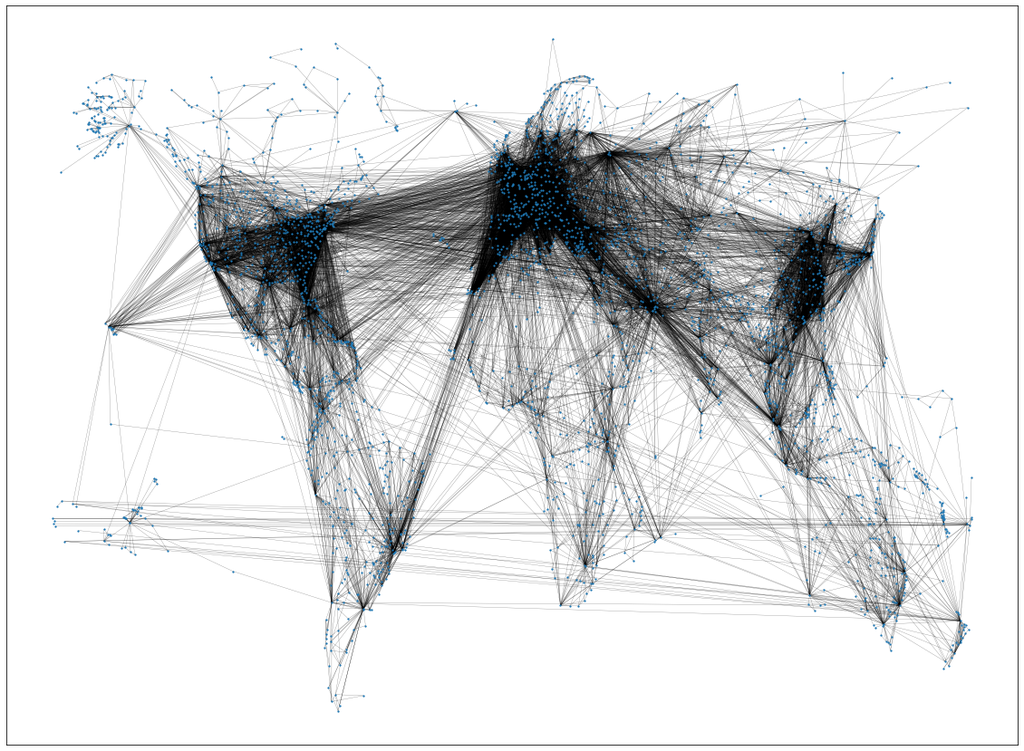

```python
main_subgraph = max(nx.connected_components(network), key= len)

network_main = network.subgraph(main_subgraph)



for airport in network_main.nodes():
    network_main.node[airport]['coordinates'] = (network_main.node[airport]['long'],
                                                 network_main.node[airport]['lat'] )




plt.figure(figsize = (20, 15))
nx.draw_networkx_nodes(network_main, nx.get_node_attributes(network_main, 'coordinates'), node_shape = '.' , node_size = 6)
nx.draw_networkx_edges(network_main, nx.get_node_attributes(network_main, 'coordinates'), width = 0.3 , alpha = 0.5)
plt.show()
```